None

# Проект: "Стримчик" смотрит в будущее

# Проект: "Стримчик" смотрит в будущее

## Введение

### Описание проекта

Мы работаем в интернет-магазине «Стримчик», который продаёт по всему миру компьютерные игры. Из открытых источников доступны исторические данные о продажах игр, оценки пользователей и экспертов, жанры и платформы (например, Xbox или PlayStation).

**Цели исследования**:

- Нужно выявить определяющие успешность игры закономерности. Это позволит сделать ставку на потенциально популярный продукт и спланировать рекламные кампании.
- Нужно отработать принцип работы с данными для прогнозирования кампаний на будущие года. Перед нами данные до 2016 года. Представим, что сейчас декабрь 2016 г., и мы планируем кампанию на 2017-й. (Неважно, прогнозируем ли мы продажи на 2017 год по данным 2016-го или же 2027-й — по данным 2026 года.)

#### Описание данных

**Названия колонок**:

- `Name` — название игры
- `Platform` — платформа
- `Year_of_Release` — год выпуска
- `Genre` — жанр игры
- `NA_sales` — продажи в Северной Америке (миллионы проданных копий)
- `EU_sales` — продажи в Европе (миллионы проданных копий)
- `JP_sales` — продажи в Японии (миллионы проданных копий)
- `Other_sales` — продажи в других странах (миллионы проданных копий)
- `Critic_Score` — оценка критиков (максимум 100)
- `User_Score` — оценка пользователей (максимум 10)
- `Rating` — рейтинг от организации ESRB (англ. Entertainment Software Rating Board). Эта ассоциация определяет рейтинг компьютерных игр и присваивает им подходящую возрастную категорию, например, «Для взрослых», «Для детей младшего возраста» или «Для подростков».

Данные за 2016 год могут быть неполными.

**Библиотеки** и настройки

```python
import pandas as pd
import matplotlib.pyplot as plt
import numpy as np
# для игнорирования ошибок
import warnings
warnings.filterwarnings("ignore")
# для регулярных выражений
import re
# для увеличения окна вывода
pd.options.display.max_rows = 300
# для проверки гипотиз
from scipy import stats as st
```

Откроем файл. Отметим, что нужно переименовать столбцы и проверить типы данных.

```python
# для ревьюера
data = pd.read_csv('/datasets/games.csv')
# локальная версия
# data = pd.read_csv('games.csv')
data.head()
```

|  | Name | Platform | Year_of_Release | Genre | NA_sales | EU_sales | JP_sales | Other_sales | Critic_Score | User_Score | Rating |
| --- | --- | --- | --- | --- | --- | --- | --- | --- | --- | --- | --- |
| 0 | Wii Sports | Wii | 2006.0 | Sports | 41.36 | 28.96 | 3.77 | 8.45 | 76.0 | 8 | E |
| 1 | Super Mario Bros. | NES | 1985.0 | Platform | 29.08 | 3.58 | 6.81 | 0.77 | NaN | NaN | NaN |
| 2 | Mario Kart Wii | Wii | 2008.0 | Racing | 15.68 | 12.76 | 3.79 | 3.29 | 82.0 | 8.3 | E |
| 3 | Wii Sports Resort | Wii | 2009.0 | Sports | 15.61 | 10.93 | 3.28 | 2.95 | 80.0 | 8 | E |
| 4 | Pokemon Red/Pokemon Blue | GB | 1996.0 | Role-Playing | 11.27 | 8.89 | 10.22 | 1.00 | NaN | NaN | NaN |

Посмотрим общую информацию. Отметим, что нужно обработать пропуски.

```python
data.info()
```

```
<class 'pandas.core.frame.DataFrame'>
RangeIndex: 16715 entries, 0 to 16714
Data columns (total 11 columns):
 #   Column           Non-Null Count  Dtype
---  ------           --------------  -----
 0   Name             16713 non-null  object
 1   Platform         16715 non-null  object
 2   Year_of_Release  16446 non-null  float64
 3   Genre            16713 non-null  object
 4   NA_sales         16715 non-null  float64
 5   EU_sales         16715 non-null  float64
 6   JP_sales         16715 non-null  float64
 7   Other_sales      16715 non-null  float64
 8   Critic_Score     8137 non-null   float64
 9   User_Score       10014 non-null  object
 10  Rating           9949 non-null   object
dtypes: float64(6), object(5)
memory usage: 1.4+ MB
```

Проверим на полные дубликаты.

```python
data.duplicated().sum()
```

```
0
```

Посмотрим зависимость столбцов друг от друга.

```python
data.corr()
```

|  | Year_of_Release | NA_sales | EU_sales | JP_sales | Other_sales | Critic_Score |
| --- | --- | --- | --- | --- | --- | --- |
| Year_of_Release | 1.000000 | -0.092500 | 0.003978 | -0.168366 | 0.037820 | 0.011411 |
| NA_sales | -0.092500 | 1.000000 | 0.765335 | 0.449594 | 0.638649 | 0.240755 |
| EU_sales | 0.003978 | 0.765335 | 1.000000 | 0.435061 | 0.722792 | 0.220752 |
| JP_sales | -0.168366 | 0.449594 | 0.435061 | 1.000000 | 0.291089 | 0.152593 |
| Other_sales | 0.037820 | 0.638649 | 0.722792 | 0.291089 | 1.000000 | 0.198554 |
| Critic_Score | 0.011411 | 0.240755 | 0.220752 | 0.152593 | 0.198554 | 1.000000 |

Немного визуализации.

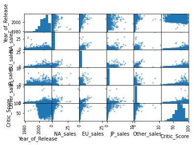

```python
pd.plotting.scatter_matrix(data)
plt.show()
```

## Преподготовка данных

### Переименование колонок

```python
data.columns
```

```
Index(['Name', 'Platform', 'Year_of_Release', 'Genre', 'NA_sales', 'EU_sales',
       'JP_sales', 'Other_sales', 'Critic_Score', 'User_Score', 'Rating'],
      dtype='object')
```

```python
data.columns = ['name', 'platform', 'year_of_release', 'genre', 'na_sales', 'eu_sales', 'jp_sales', 'other_sales', \
                'critic_score', 'user_score', 'rating']
# data.head()
```

**Новые названия колонок**:

- `name` — название игры
- `platform` — платформа
- `year_of_release` — год выпуска
- `genre` — жанр игры
- `na_sales` — продажи в Северной Америке (миллионы проданных копий)
- `eu_sales` — продажи в Европе (миллионы проданных копий)
- `jp_sales` — продажи в Японии (миллионы проданных копий)
- `other_sales` — продажи в других странах (миллионы проданных копий)
- `critic_score` — оценка критиков (максимум 100)
- `user_score` — оценка пользователей (максимум 10)
- `rating` — рейтинг от организации ESRB

### Типы данных

Оптимизация типов данных позволяет:

- экономить машинные ресурсы: память, время процессора,
- ускорять обработку данных,
- делает данные более понятными и наглядными для человека.

```python
data.info()
```

```
<class 'pandas.core.frame.DataFrame'>
RangeIndex: 16715 entries, 0 to 16714
Data columns (total 11 columns):
 #   Column           Non-Null Count  Dtype
---  ------           --------------  -----
 0   name             16713 non-null  object
 1   platform         16715 non-null  object
 2   year_of_release  16446 non-null  float64
 3   genre            16713 non-null  object
 4   na_sales         16715 non-null  float64
 5   eu_sales         16715 non-null  float64
 6   jp_sales         16715 non-null  float64
 7   other_sales      16715 non-null  float64
 8   critic_score     8137 non-null   float64
 9   user_score       10014 non-null  object
 10  rating           9949 non-null   object
dtypes: float64(6), object(5)
memory usage: 1.4+ MB
```

```python
data.head()
```

|  | name | platform | year_of_release | genre | na_sales | eu_sales | jp_sales | other_sales | critic_score | user_score | rating |
| --- | --- | --- | --- | --- | --- | --- | --- | --- | --- | --- | --- |
| 0 | Wii Sports | Wii | 2006.0 | Sports | 41.36 | 28.96 | 3.77 | 8.45 | 76.0 | 8 | E |
| 1 | Super Mario Bros. | NES | 1985.0 | Platform | 29.08 | 3.58 | 6.81 | 0.77 | NaN | NaN | NaN |
| 2 | Mario Kart Wii | Wii | 2008.0 | Racing | 15.68 | 12.76 | 3.79 | 3.29 | 82.0 | 8.3 | E |
| 3 | Wii Sports Resort | Wii | 2009.0 | Sports | 15.61 | 10.93 | 3.28 | 2.95 | 80.0 | 8 | E |
| 4 | Pokemon Red/Pokemon Blue | GB | 1996.0 | Role-Playing | 11.27 | 8.89 | 10.22 | 1.00 | NaN | NaN | NaN |

Из представленных колонок и типов данных в них будет логично поменять типы данных на следующие

- `year_of_release` — формат даты
- `critic_score` — на целочисленный
- `user_score` — на вещественный

#### `year_of_reliase` - будет первым. Проверим и приведём к формату даты.

```python
data['year_of_release'].unique()
```

```
array([2006., 1985., 2008., 2009., 1996., 1989., 1984., 2005., 1999.,
       2007., 2010., 2013., 2004., 1990., 1988., 2002., 2001., 2011.,
       1998., 2015., 2012., 2014., 1992., 1997., 1993., 1994., 1982.,
       2016., 2003., 1986., 2000.,   nan, 1995., 1991., 1981., 1987.,
       1980., 1983.])
```

```python
data['year_of_release'] = np.floor(pd.to_numeric(data['year_of_release'], errors='coerce')).astype('Int16')
#data['year_of_release'] = pd.to_datetime(data['year_of_release'], format='%Y')
#data['year_of_release'] = data['year_of_release'].dt.year
data['year_of_release'].unique()
```

```
<IntegerArray>
[2006, 1985, 2008, 2009, 1996, 1989, 1984, 2005, 1999, 2007, 2010, 2013, 2004,
 1990, 1988, 2002, 2001, 2011, 1998, 2015, 2012, 2014, 1992, 1997, 1993, 1994,
 1982, 2016, 2003, 1986, 2000, <NA>, 1995, 1991, 1981, 1987, 1980, 1983]
Length: 38, dtype: Int16
```

#### `critic_score` — проверим и приведем к целочисленным.

```python
data['critic_score'].unique()
```

```
array([76., nan, 82., 80., 89., 58., 87., 91., 61., 97., 95., 77., 88.,
       83., 94., 93., 85., 86., 98., 96., 90., 84., 73., 74., 78., 92.,
       71., 72., 68., 62., 49., 67., 81., 66., 56., 79., 70., 59., 64.,
       75., 60., 63., 69., 50., 25., 42., 44., 55., 48., 57., 29., 47.,
       65., 54., 20., 53., 37., 38., 33., 52., 30., 32., 43., 45., 51.,
       40., 46., 39., 34., 35., 41., 36., 28., 31., 27., 26., 19., 23.,
       24., 21., 17., 22., 13.])
```

```python
data['critic_score'] = np.floor(pd.to_numeric(data['critic_score'], errors='coerce')).astype('Int8')
data['critic_score'].unique()
```

```
<IntegerArray>
[  76, <NA>,   82,   80,   89,   58,   87,   91,   61,   97,   95,   77,   88,
   83,   94,   93,   85,   86,   98,   96,   90,   84,   73,   74,   78,   92,
   71,   72,   68,   62,   49,   67,   81,   66,   56,   79,   70,   59,   64,
   75,   60,   63,   69,   50,   25,   42,   44,   55,   48,   57,   29,   47,
   65,   54,   20,   53,   37,   38,   33,   52,   30,   32,   43,   45,   51,
   40,   46,   39,   34,   35,   41,   36,   28,   31,   27,   26,   19,   23,
   24,   21,   17,   22,   13]
Length: 83, dtype: Int8
```

#### `user_score` — проверим и приведем к вещественному типу, а потом и к целому.

```python
data['user_score'].unique()
```

```
array(['8', nan, '8.3', '8.5', '6.6', '8.4', '8.6', '7.7', '6.3', '7.4',
       '8.2', '9', '7.9', '8.1', '8.7', '7.1', '3.4', '5.3', '4.8', '3.2',
       '8.9', '6.4', '7.8', '7.5', '2.6', '7.2', '9.2', '7', '7.3', '4.3',
       '7.6', '5.7', '5', '9.1', '6.5', 'tbd', '8.8', '6.9', '9.4', '6.8',
       '6.1', '6.7', '5.4', '4', '4.9', '4.5', '9.3', '6.2', '4.2', '6',
       '3.7', '4.1', '5.8', '5.6', '5.5', '4.4', '4.6', '5.9', '3.9',
       '3.1', '2.9', '5.2', '3.3', '4.7', '5.1', '3.5', '2.5', '1.9', '3',
       '2.7', '2.2', '2', '9.5', '2.1', '3.6', '2.8', '1.8', '3.8', '0',
       '1.6', '9.6', '2.4', '1.7', '1.1', '0.3', '1.5', '0.7', '1.2',
       '2.3', '0.5', '1.3', '0.2', '0.6', '1.4', '0.9', '1', '9.7'],
      dtype=object)
```

##### TBD

```python
# что такое tbd и как оно выглядит.
display (data[data['user_score'] == 'tbd'].head())
data[data['user_score'] == 'tbd'].count()
# в переводе "будет решено или определено"
```

|  | name | platform | year_of_release | genre | na_sales | eu_sales | jp_sales | other_sales | critic_score | user_score | rating |
| --- | --- | --- | --- | --- | --- | --- | --- | --- | --- | --- | --- |
| 119 | Zumba Fitness | Wii | 2010 | Sports | 3.45 | 2.59 | 0.0 | 0.66 | <NA> | tbd | E |
| 301 | Namco Museum: 50th Anniversary | PS2 | 2005 | Misc | 2.08 | 1.35 | 0.0 | 0.54 | 61 | tbd | E10+ |
| 520 | Zumba Fitness 2 | Wii | 2011 | Sports | 1.51 | 1.03 | 0.0 | 0.27 | <NA> | tbd | T |
| 645 | uDraw Studio | Wii | 2010 | Misc | 1.65 | 0.57 | 0.0 | 0.20 | 71 | tbd | E |
| 657 | Frogger's Adventures: Temple of the Frog | GBA | <NA> | Adventure | 2.15 | 0.18 | 0.0 | 0.07 | 73 | tbd | E |

```
name               2424
platform           2424
year_of_release    2376
genre              2424
na_sales           2424
eu_sales           2424
jp_sales           2424
other_sales        2424
critic_score       1082
user_score         2424
rating             2374
dtype: int64
```

На этапе проверки мы обнаружили значение 'tbd' в столбце `user_score`. Этих значений 2424 мы не можем этого проигнорировать.

**TBD** - это абривиатура "будет определено позже". Скорее всего рейтинги для этих игр не были определёны на этапе сбора данных. И так как база данных за 2016 год, а есть игры от 2005 года, то может и не будут определены. Поэтому лучше эти значения приравнять к пропускам.

```python
data['user_score'].replace('tbd', np.NaN, inplace=True)
# display (data[data['user_score'] == 'tbd'].head())
data[data['user_score'] == 'tbd'].count()
```

```
name               0
platform           0
year_of_release    0
genre              0
na_sales           0
eu_sales           0
jp_sales           0
other_sales        0
critic_score       0
user_score         0
rating             0
dtype: int64
```

Вот так благодаря **TBD** мы получили еще 2424 пропуска!

А теперь закончим с типами данных.

```python
data['user_score'] = pd.to_numeric(data['user_score'], errors='coerce', downcast='float')
data['user_score'].unique()
```

```
array([8. , nan, 8.3, 8.5, 6.6, 8.4, 8.6, 7.7, 6.3, 7.4, 8.2, 9. , 7.9,
       8.1, 8.7, 7.1, 3.4, 5.3, 4.8, 3.2, 8.9, 6.4, 7.8, 7.5, 2.6, 7.2,
       9.2, 7. , 7.3, 4.3, 7.6, 5.7, 5. , 9.1, 6.5, 8.8, 6.9, 9.4, 6.8,
       6.1, 6.7, 5.4, 4. , 4.9, 4.5, 9.3, 6.2, 4.2, 6. , 3.7, 4.1, 5.8,
       5.6, 5.5, 4.4, 4.6, 5.9, 3.9, 3.1, 2.9, 5.2, 3.3, 4.7, 5.1, 3.5,
       2.5, 1.9, 3. , 2.7, 2.2, 2. , 9.5, 2.1, 3.6, 2.8, 1.8, 3.8, 0. ,
       1.6, 9.6, 2.4, 1.7, 1.1, 0.3, 1.5, 0.7, 1.2, 2.3, 0.5, 1.3, 0.2,
       0.6, 1.4, 0.9, 1. , 9.7], dtype=float32)
```

```python
data.info()
```

```
<class 'pandas.core.frame.DataFrame'>
RangeIndex: 16715 entries, 0 to 16714
Data columns (total 11 columns):
 #   Column           Non-Null Count  Dtype
---  ------           --------------  -----
 0   name             16713 non-null  object
 1   platform         16715 non-null  object
 2   year_of_release  16446 non-null  Int16
 3   genre            16713 non-null  object
 4   na_sales         16715 non-null  float64
 5   eu_sales         16715 non-null  float64
 6   jp_sales         16715 non-null  float64
 7   other_sales      16715 non-null  float64
 8   critic_score     8137 non-null   Int8
 9   user_score       7590 non-null   float32
 10  rating           9949 non-null   object
dtypes: Int16(1), Int8(1), float32(1), float64(4), object(4)
memory usage: 1.2+ MB
```

**Вывод**: мы привели столбцы к оптимальным типам данных. Но стоит заметить, что рейтинги от критиков и пользователей различиются в 10 раз.

Приведем рейтинги от пользователей к тому же формату и типу данных, что у критиков.

Теперь нам будет очень легко сравнивать мнения критиков с пользователей.

```python
data['user_score'] = data['user_score'] * 10
data['user_score'] = np.floor(pd.to_numeric(data['user_score'], errors='coerce')).astype('Int8')
# data['user_score'].astype('int8', copy = True, errors= 'ignore')
data['user_score'].unique()
```

```
<IntegerArray>
[  80, <NA>,   83,   85,   66,   84,   86,   77,   63,   74,   82,   90,   79,
   81,   87,   71,   34,   53,   48,   32,   89,   64,   78,   75,   26,   72,
   92,   70,   73,   43,   76,   57,   50,   91,   65,   88,   69,   94,   68,
   61,   67,   54,   40,   49,   45,   93,   62,   42,   60,   37,   41,   58,
   56,   55,   44,   46,   59,   39,   31,   29,   52,   33,   47,   51,   35,
   25,   19,   30,   27,   22,   20,   95,   21,   36,   28,   18,   38,    0,
   16,   96,   24,   17,   11,    3,   15,    7,   12,   23,    5,   13,    2,
    6,   14,    9,   10,   97]
Length: 96, dtype: Int8
```

### Обработка пропусков

```python
data.isna().sum()
```

```
name                  2
platform              0
year_of_release     269
genre                 2
na_sales              0
eu_sales              0
jp_sales              0
other_sales           0
critic_score       8578
user_score         9125
rating             6766
dtype: int64
```

На первый взгляд у нас очень много пропусков.

Скорее всего они получились из-за:

- технических трудностей при сборе данных и объединении данных,
- человеческих ошибок,
- по объективным причинам, например рейтинги на некоторые игры не измерялись на всех рынках,
- актуальности данных на момент сбора данных, например, ситуация с TBD выше, которая, дала нам дополнительные пропуски.

Но основное количество пропусков, у нас в рейтингах от критиков, пользователей и ESRB. К сожалению, нам придется смириться с пропусками, так как мы не критики, не пользователи и тем более не ESRB. Будем надеяться, что их число уменьшеться на этапе обработки неявных дубликатов. И для ESRB мы можем расширить их рейтинги все платформы для каждой из игр. А так будем работать с тем, что есть.

И так ... "решим, то что можем решить, а там посмотрим".

Обработаем пропуски в следующих столбцах:

- `name` — название игры
- `year_of_release` — год выпуска
- `genre` — жанр игры
- `rating` — рейтинг от организации ESRB

#### `name`, `genre` - пропуски

```python
data[data['name'].isna()]
```

|  | name | platform | year_of_release | genre | na_sales | eu_sales | jp_sales | other_sales | critic_score | user_score | rating |
| --- | --- | --- | --- | --- | --- | --- | --- | --- | --- | --- | --- |
| 659 | NaN | GEN | 1993 | NaN | 1.78 | 0.53 | 0.00 | 0.08 | <NA> | <NA> | NaN |
| 14244 | NaN | GEN | 1993 | NaN | 0.00 | 0.00 | 0.03 | 0.00 | <NA> | <NA> | NaN |

```python
nan_name = data['name'].isna().sum() / len(data)
display(f'Процент пропусков от общего числа данных {nan_name:.0%}')
```

```
'Процент пропусков от общего числа данных 0%'
```

```python
data[data['year_of_release'] == 1993].head()
```

|  | name | platform | year_of_release | genre | na_sales | eu_sales | jp_sales | other_sales | critic_score | user_score | rating |
| --- | --- | --- | --- | --- | --- | --- | --- | --- | --- | --- | --- |
| 56 | Super Mario All-Stars | SNES | 1993 | Platform | 5.99 | 2.15 | 2.12 | 0.29 | <NA> | <NA> | NaN |
| 476 | Star Fox | SNES | 1993 | Shooter | 1.61 | 0.51 | 0.80 | 0.07 | <NA> | <NA> | NaN |
| 659 | NaN | GEN | 1993 | NaN | 1.78 | 0.53 | 0.00 | 0.08 | <NA> | <NA> | NaN |
| 852 | Super Street Fighter II | SNES | 1993 | Fighting | 0.52 | 0.16 | 1.29 | 0.03 | <NA> | <NA> | NaN |
| 892 | Mortal Kombat II | SNES | 1993 | Fighting | 1.48 | 0.39 | 0.00 | 0.06 | <NA> | <NA> | NaN |

```python
data[data['platform'] == 'GEN']
```

|  | name | platform | year_of_release | genre | na_sales | eu_sales | jp_sales | other_sales | critic_score | user_score | rating |
| --- | --- | --- | --- | --- | --- | --- | --- | --- | --- | --- | --- |
| 145 | Sonic the Hedgehog 2 | GEN | 1992 | Platform | 4.47 | 1.20 | 0.16 | 0.19 | <NA> | <NA> | NaN |
| 257 | Sonic the Hedgehog | GEN | 1991 | Platform | 3.03 | 0.91 | 0.26 | 0.13 | <NA> | <NA> | NaN |
| 564 | Mortal Kombat | GEN | 1992 | Fighting | 1.95 | 0.63 | 0.00 | 0.09 | <NA> | <NA> | NaN |
| 588 | Streets of Rage | GEN | 1990 | Action | 1.86 | 0.55 | 0.11 | 0.08 | <NA> | <NA> | NaN |
| 659 | NaN | GEN | 1993 | NaN | 1.78 | 0.53 | 0.00 | 0.08 | <NA> | <NA> | NaN |
| 832 | NBA Jam | GEN | 1992 | Sports | 1.75 | 0.25 | 0.00 | 0.05 | <NA> | <NA> | NaN |
| 960 | Sonic & Knuckles | GEN | 1994 | Platform | 1.24 | 0.43 | 0.03 | 0.12 | <NA> | <NA> | NaN |
| 996 | Sonic the Hedgehog 3 | GEN | 1994 | Platform | 1.02 | 0.47 | 0.20 | 0.07 | <NA> | <NA> | NaN |
| 1099 | Street Fighter II': Special Champion Edition | GEN | 1992 | Fighting | 1.00 | 0.30 | 0.31 | 0.04 | <NA> | <NA> | NaN |
| 1365 | Disney's The Lion King | GEN | 1994 | Platform | 0.97 | 0.37 | 0.03 | 0.05 | <NA> | <NA> | NaN |
| 1453 | Mortal Kombat 3 | GEN | 1994 | Fighting | 1.03 | 0.27 | 0.00 | 0.04 | <NA> | <NA> | NaN |
| 1842 | NBA Jam Tournament Edition | GEN | 1994 | Sports | 0.95 | 0.14 | 0.00 | 0.03 | <NA> | <NA> | NaN |
| 6451 | Virtua Racing | GEN | 1994 | Racing | 0.00 | 0.00 | 0.26 | 0.00 | <NA> | <NA> | NaN |
| 7885 | Shining Force II | GEN | 1993 | Strategy | 0.00 | 0.00 | 0.19 | 0.00 | <NA> | <NA> | NaN |
| 8893 | Super Street Fighter II | GEN | 1993 | Fighting | 0.00 | 0.00 | 0.15 | 0.00 | <NA> | <NA> | NaN |
| 9000 | Lunar 2: Eternal Blue(sales, but wrong system) | GEN | 1994 | Role-Playing | 0.00 | 0.00 | 0.14 | 0.00 | <NA> | <NA> | NaN |
| 9563 | Gunstar Heroes | GEN | 1992 | Shooter | 0.00 | 0.00 | 0.13 | 0.00 | <NA> | <NA> | NaN |
| 9787 | Ecco the Dolphin | GEN | 1992 | Adventure | 0.00 | 0.00 | 0.12 | 0.00 | <NA> | <NA> | NaN |
| 11563 | Yuu Yuu Hakusho: Makyo Toitsusen | GEN | 1994 | Fighting | 0.00 | 0.00 | 0.08 | 0.00 | <NA> | <NA> | NaN |
| 11660 | Dragon Slayer: The Legend of Heroes | GEN | 1994 | Role-Playing | 0.00 | 0.00 | 0.08 | 0.00 | <NA> | <NA> | NaN |
| 11986 | Ecco: The Tides of Time | GEN | 1993 | Adventure | 0.00 | 0.00 | 0.07 | 0.00 | <NA> | <NA> | NaN |
| 12098 | Street Fighter II': Special Champion Edition (... | GEN | 1993 | Action | 0.00 | 0.00 | 0.07 | 0.00 | <NA> | <NA> | NaN |
| 12264 | Streets of Rage 3 | GEN | 1993 | Action | 0.00 | 0.00 | 0.07 | 0.00 | <NA> | <NA> | NaN |
| 12984 | Dynamite Headdy | GEN | 1993 | Platform | 0.00 | 0.00 | 0.05 | 0.00 | <NA> | <NA> | NaN |
| 13343 | Beyond Oasis | GEN | 1993 | Role-Playing | 0.00 | 0.00 | 0.05 | 0.00 | <NA> | <NA> | NaN |
| 14085 | J-League Pro Striker 2 | GEN | 1994 | Sports | 0.00 | 0.00 | 0.04 | 0.00 | <NA> | <NA> | NaN |
| 14132 | Castlevania Bloodlines | GEN | 1994 | Platform | 0.00 | 0.00 | 0.04 | 0.00 | <NA> | <NA> | NaN |
| 14244 | NaN | GEN | 1993 | NaN | 0.00 | 0.00 | 0.03 | 0.00 | <NA> | <NA> | NaN |
| 14488 | Puzzle & Action: Tant-R | GEN | 1994 | Misc | 0.00 | 0.00 | 0.03 | 0.00 | <NA> | <NA> | NaN |

К сожалению, названия платформы и года выпуска не достаточно, чтобы востановить данные для более чем 2 миллионов продаж. Удаляем эти строки. К счастью, эти же строки удалят пропуски в столбце `genre`.

```python
data.dropna(subset = ['name'], inplace=True)
data.isna().sum()
```

```
name                  0
platform              0
year_of_release     269
genre                 0
na_sales              0
eu_sales              0
jp_sales              0
other_sales           0
critic_score       8576
user_score         9123
rating             6764
dtype: int64
```

#### `year_of_release` - пропуски

```python
display ('Количество пропусков в столбце year_of_release', data['year_of_release'].isna().sum())
nan_year_of_release = data['year_of_release'].isna().sum() / len(data)
display(f'Процент пропусков от общего числа данных {nan_year_of_release:.1%}')
```

```
'Количество пропусков в столбце year_of_release'
```

```
269
```

```
'Процент пропусков от общего числа данных 1.6%'
```

```python
data[data['year_of_release'].isna()].head(20)
```

|  | name | platform | year_of_release | genre | na_sales | eu_sales | jp_sales | other_sales | critic_score | user_score | rating |
| --- | --- | --- | --- | --- | --- | --- | --- | --- | --- | --- | --- |
| 183 | Madden NFL 2004 | PS2 | <NA> | Sports | 4.26 | 0.26 | 0.01 | 0.71 | 94 | 85 | E |
| 377 | FIFA Soccer 2004 | PS2 | <NA> | Sports | 0.59 | 2.36 | 0.04 | 0.51 | 84 | 64 | E |
| 456 | LEGO Batman: The Videogame | Wii | <NA> | Action | 1.80 | 0.97 | 0.00 | 0.29 | 74 | 79 | E10+ |
| 475 | wwe Smackdown vs. Raw 2006 | PS2 | <NA> | Fighting | 1.57 | 1.02 | 0.00 | 0.41 | <NA> | <NA> | NaN |
| 609 | Space Invaders | 2600 | <NA> | Shooter | 2.36 | 0.14 | 0.00 | 0.03 | <NA> | <NA> | NaN |
| 627 | Rock Band | X360 | <NA> | Misc | 1.93 | 0.33 | 0.00 | 0.21 | 92 | 82 | T |
| 657 | Frogger's Adventures: Temple of the Frog | GBA | <NA> | Adventure | 2.15 | 0.18 | 0.00 | 0.07 | 73 | <NA> | E |
| 678 | LEGO Indiana Jones: The Original Adventures | Wii | <NA> | Action | 1.51 | 0.61 | 0.00 | 0.21 | 78 | 66 | E10+ |
| 719 | Call of Duty 3 | Wii | <NA> | Shooter | 1.17 | 0.84 | 0.00 | 0.23 | 69 | 67 | T |
| 805 | Rock Band | Wii | <NA> | Misc | 1.33 | 0.56 | 0.00 | 0.20 | 80 | 63 | T |
| 1131 | Call of Duty: Black Ops | PC | <NA> | Shooter | 0.58 | 0.81 | 0.00 | 0.23 | 81 | 52 | M |
| 1142 | Rock Band | PS3 | <NA> | Misc | 0.99 | 0.41 | 0.00 | 0.22 | 92 | 84 | T |
| 1301 | Triple Play 99 | PS | <NA> | Sports | 0.81 | 0.55 | 0.00 | 0.10 | <NA> | <NA> | NaN |
| 1506 | Adventure | 2600 | <NA> | Adventure | 1.21 | 0.08 | 0.00 | 0.01 | <NA> | <NA> | NaN |
| 1538 | LEGO Batman: The Videogame | PSP | <NA> | Action | 0.57 | 0.44 | 0.00 | 0.27 | 73 | 74 | E10+ |
| 1585 | Combat | 2600 | <NA> | Action | 1.17 | 0.07 | 0.00 | 0.01 | <NA> | <NA> | NaN |
| 1609 | LEGO Harry Potter: Years 5-7 | Wii | <NA> | Action | 0.69 | 0.42 | 0.00 | 0.12 | 76 | 78 | E10+ |
| 1650 | NASCAR Thunder 2003 | PS2 | <NA> | Racing | 0.60 | 0.46 | 0.00 | 0.16 | 84 | 87 | E |
| 1699 | Hitman 2: Silent Assassin | XB | <NA> | Action | 0.76 | 0.38 | 0.00 | 0.05 | 84 | 80 | M |
| 1840 | Rock Band | PS2 | <NA> | Misc | 0.71 | 0.06 | 0.00 | 0.35 | 82 | 68 | T |

Сделаем допущение, что игры выходили в один и тот же год на всех платформах. И заполним пропуски, где указан год выпуска игры хотя бы для одной платформы.

```python
# проверим были ли игры у которых указан год на одних платформах, но не указан на других платформах.
# указаный год присвоим всем платформам для этой игры
k = 0

for column_value, column_slice in data.groupby('name'):
    if (column_slice['year_of_release'].isna().sum() > 0 ) & (column_slice['year_of_release'].notna().sum() > 0):
        try:
            year = column_slice.loc[column_slice['year_of_release'].notna(), 'year_of_release'].head(1).item()
            data.loc[data['name'] == column_value, 'year_of_release'] = year
        except: k +=1

display('Количество ошибок', k)
```

```
'Количество ошибок'
```

```
0
```

```python
# data['year_of_release'].unique()
```

```python
display ('Количество пропусков в столбце year_of_release', data['year_of_release'].isna().sum())
nan_year_of_release = data['year_of_release'].isna().sum() / len(data)
display(f'Процент пропусков от общего числа данных {nan_year_of_release:.1%}')
```

```
'Количество пропусков в столбце year_of_release'
```

```
146
```

```
'Процент пропусков от общего числа данных 0.9%'
```

Не плохо получилось с платформами.

Теперь сделаем допущение, что год указанный в названии игры, так же является годом выпуска игры. И заполним пропуски в годах выпуска датами из названий. Не будем забывать, что у нас база с 1980 года по 2016.

```python
# посмотрим названия игр на содержание года выпуска в названии, но без года выпуска и сохраним список
name_with_nan_year_or_release = data[data['year_of_release'].isna()]['name'].unique()
# name_with_nan_year_or_release

# import re

for name in name_with_nan_year_or_release:
    year = re.findall(r'\d+$', name)
    if year !=[]:
        year = pd.to_numeric(year[0], downcast = 'integer')
        if year > 80 and year < 100:
            year = year + 1900
#            year = pd.to_datetime(year, errors='ignore', format='%Y')
#            display( name, year)
            data.loc[data['name'] == name, 'year_of_release'] = year
        elif year >= 2000:
#            year = pd.to_datetime(year, errors='ignore', format='%Y')
            data.loc[data['name'] == name, 'year_of_release'] = year
 #           display( name, year)
```

```python
display ('Количество пропусков в столбце year_of_release', data['year_of_release'].isna().sum())
nan_year_of_release = data['year_of_release'].isna().sum() / len(data)
display(f'Процент пропусков от общего числа данных {nan_year_of_release:.1%}')
```

```
'Количество пропусков в столбце year_of_release'
```

```
138
```

```
'Процент пропусков от общего числа данных 0.8%'
```

Мы сократили число пропусков на 0,1%... Востановить оставшиеся пропуски в столбце года выпуска не представляется возможным. Удалим строки, которые их содержат.

```python
# удалим строки с оставшимися пропусками, так год не воставновить, а данных менее 1%
data.dropna(subset=['year_of_release'], inplace=True)
data.info()
```

```
<class 'pandas.core.frame.DataFrame'>
Int64Index: 16575 entries, 0 to 16714
Data columns (total 11 columns):
 #   Column           Non-Null Count  Dtype
---  ------           --------------  -----
 0   name             16575 non-null  object
 1   platform         16575 non-null  object
 2   year_of_release  16575 non-null  Int16
 3   genre            16575 non-null  object
 4   na_sales         16575 non-null  float64
 5   eu_sales         16575 non-null  float64
 6   jp_sales         16575 non-null  float64
 7   other_sales      16575 non-null  float64
 8   critic_score     8079 non-null   Int8
 9   user_score       7543 non-null   Int8
 10  rating           9871 non-null   object
dtypes: Int16(1), Int8(2), float64(4), object(4)
memory usage: 1.2+ MB
```

#### `rating`- пропуски и актуализация рейтингов

```python
display ('Количество пропусков в столбце rating', data['rating'].isna().sum())
nan_rating = data['rating'].isna().sum() / len(data)
display(f'Процент пропусков от общего числа данных {nan_rating:.1%}')
```

```
'Количество пропусков в столбце rating'
```

```
6704
```

```
'Процент пропусков от общего числа данных 40.4%'
```

```python
data['rating'].value_counts()
```

```
E       3961
T       2930
M       1554
E10+    1412
EC         8
K-A        3
RP         2
AO         1
Name: rating, dtype: int64
```

```python
# Комментарий ревьюера
temp = data.copy()
temp.query('name == "Need for Speed: Most Wanted"')
```

|  | name | platform | year_of_release | genre | na_sales | eu_sales | jp_sales | other_sales | critic_score | user_score | rating |
| --- | --- | --- | --- | --- | --- | --- | --- | --- | --- | --- | --- |
| 253 | Need for Speed: Most Wanted | PS2 | 2005 | Racing | 2.03 | 1.79 | 0.08 | 0.47 | 82 | 91 | T |
| 523 | Need for Speed: Most Wanted | PS3 | 2012 | Racing | 0.71 | 1.46 | 0.06 | 0.58 | <NA> | <NA> | NaN |
| 1190 | Need for Speed: Most Wanted | X360 | 2012 | Racing | 0.62 | 0.78 | 0.01 | 0.15 | 83 | 85 | T |
| 1591 | Need for Speed: Most Wanted | X360 | 2005 | Racing | 1.00 | 0.13 | 0.02 | 0.10 | 83 | 85 | T |
| 1998 | Need for Speed: Most Wanted | XB | 2005 | Racing | 0.53 | 0.46 | 0.00 | 0.05 | 83 | 88 | T |
| 2048 | Need for Speed: Most Wanted | PSV | 2012 | Racing | 0.33 | 0.45 | 0.01 | 0.22 | <NA> | <NA> | NaN |
| 3581 | Need for Speed: Most Wanted | GC | 2005 | Racing | 0.43 | 0.11 | 0.00 | 0.02 | 80 | 91 | T |
| 5972 | Need for Speed: Most Wanted | PC | 2005 | Racing | 0.02 | 0.23 | 0.00 | 0.04 | 82 | 85 | T |
| 6273 | Need for Speed: Most Wanted | WiiU | 2013 | Racing | 0.13 | 0.12 | 0.00 | 0.02 | <NA> | <NA> | NaN |
| 6410 | Need for Speed: Most Wanted | DS | 2005 | Racing | 0.24 | 0.01 | 0.00 | 0.02 | 45 | 61 | E |
| 6473 | Need for Speed: Most Wanted | GBA | 2005 | Racing | 0.19 | 0.07 | 0.00 | 0.00 | <NA> | 83 | E |
| 11715 | Need for Speed: Most Wanted | PC | 2012 | Racing | 0.00 | 0.06 | 0.00 | 0.02 | 82 | 85 | T |

```python
# Комментарий ревьюера
data.query('name == "Need for Speed: Most Wanted"')
```

|  | name | platform | year_of_release | genre | na_sales | eu_sales | jp_sales | other_sales | critic_score | user_score | rating |
| --- | --- | --- | --- | --- | --- | --- | --- | --- | --- | --- | --- |
| 253 | Need for Speed: Most Wanted | PS2 | 2005 | Racing | 2.03 | 1.79 | 0.08 | 0.47 | 82 | 91 | T |
| 523 | Need for Speed: Most Wanted | PS3 | 2012 | Racing | 0.71 | 1.46 | 0.06 | 0.58 | <NA> | <NA> | NaN |
| 1190 | Need for Speed: Most Wanted | X360 | 2012 | Racing | 0.62 | 0.78 | 0.01 | 0.15 | 83 | 85 | T |
| 1591 | Need for Speed: Most Wanted | X360 | 2005 | Racing | 1.00 | 0.13 | 0.02 | 0.10 | 83 | 85 | T |
| 1998 | Need for Speed: Most Wanted | XB | 2005 | Racing | 0.53 | 0.46 | 0.00 | 0.05 | 83 | 88 | T |
| 2048 | Need for Speed: Most Wanted | PSV | 2012 | Racing | 0.33 | 0.45 | 0.01 | 0.22 | <NA> | <NA> | NaN |
| 3581 | Need for Speed: Most Wanted | GC | 2005 | Racing | 0.43 | 0.11 | 0.00 | 0.02 | 80 | 91 | T |
| 5972 | Need for Speed: Most Wanted | PC | 2005 | Racing | 0.02 | 0.23 | 0.00 | 0.04 | 82 | 85 | T |
| 6273 | Need for Speed: Most Wanted | WiiU | 2013 | Racing | 0.13 | 0.12 | 0.00 | 0.02 | <NA> | <NA> | NaN |
| 6410 | Need for Speed: Most Wanted | DS | 2005 | Racing | 0.24 | 0.01 | 0.00 | 0.02 | 45 | 61 | E |
| 6473 | Need for Speed: Most Wanted | GBA | 2005 | Racing | 0.19 | 0.07 | 0.00 | 0.00 | <NA> | 83 | E |
| 11715 | Need for Speed: Most Wanted | PC | 2012 | Racing | 0.00 | 0.06 | 0.00 | 0.02 | 82 | 85 | T |

По информации сайта www.esrb.org эти категории можно соотнести со следующими возрастными группами (по годам), более привычными в России:

- E - 0+
- E10+ - 10+
- T - 13+
- M - 17+
- RP - рейтинг в ожидании. Иногда добавляется возрастная группа, к чему стремиться ожидание, например, 17+.
- EC - 3+. Был переименован в E.
- A - 18+. AO был переимнован в А.
- K-A - Был до 1988 года, Переименован в E

Для удобства работы:

- заполним все оставшиеся пропуски рейтингом **noESRB**.
- сделаем переименования на современный лад.

ESRB не должно на нас за это обидиться.

```python
# Исправление по замечению ревьюера ниже
# data.loc[data['rating'].isna(), 'rating'] = 'RP'
data.loc[data['rating'].isna(), 'rating'] = 'noESRB'

data.loc[data['rating'] == 'AO', 'rating'] = 'A'
data.loc[data['rating'] == 'K-A', 'rating'] = 'E'
data.loc[data['rating'] == 'EC', 'rating'] = 'E'
display(data['rating'].value_counts())

display ('Количество пропусков в столбце rating', data['rating'].isna().sum())
nan_rating = data['rating'].isna().sum() / len(data)
display(f'Процент пропусков от общего числа данных {nan_rating:.1%}')
```

```
noESRB    6704
E         3972
T         2930
M         1554
E10+      1412
RP           2
A            1
Name: rating, dtype: int64
```

```
'Количество пропусков в столбце rating'
```

```
0
```

```
'Процент пропусков от общего числа данных 0.0%'
```

### Проверка на неявные и явные дубликаты

Проверим сколько у нас явных дубликатов строк.

```python
data.duplicated().sum()
```

```
0
```

```python
data['platform'].unique()
```

```
array(['Wii', 'NES', 'GB', 'DS', 'X360', 'PS3', 'PS2', 'SNES', 'GBA',
       'PS4', '3DS', 'N64', 'PS', 'XB', 'PC', '2600', 'PSP', 'XOne',
       'WiiU', 'GC', 'GEN', 'DC', 'PSV', 'SAT', 'SCD', 'WS', 'NG', 'TG16',
       '3DO', 'GG', 'PCFX'], dtype=object)
```

```python
data['genre'].unique()
```

```
array(['Sports', 'Platform', 'Racing', 'Role-Playing', 'Puzzle', 'Misc',
       'Shooter', 'Simulation', 'Action', 'Fighting', 'Adventure',
       'Strategy'], dtype=object)
```

```python
data['rating'].unique()
```

```
array(['E', 'noESRB', 'M', 'T', 'E10+', 'A', 'RP'], dtype=object)
```

Как мы видим неявные будликаты в столбцах:

- `name` — название игры
- `platform` — платформа
- `genre` — жанр игры
- `rating` - рейтинг ESRB

Отсутствуют. В остальных колонках числовые значения.

#### `name` - неявные дубликаты

Проверим столбец `name` на дубликаты и постараемся побороться с опечатками.

```python
data['name'].value_counts()
```

```
Need for Speed: Most Wanted                        12
Madden NFL 07                                       9
Ratatouille                                         9
FIFA 14                                             9
LEGO Marvel Super Heroes                            9
                                                   ..
Wand of Fortune 2: Jikuu ni Shizumu Mokushiroku     1
Warhammer: Battle For Atluma                        1
7th Dragon 2020                                     1
Euro Truck Simulator 2                              1
Interactive Storybook DS Series 1                   1
Name: name, Length: 11433, dtype: int64
```

```python
# data['name'].unique()
```

```python
(data['name'].str.lower()
    .replace(regex={r'\W+': ' ',
                    r'\s+': ' ',
                    r'^\s+': '',
                    r'\s+$': ''
                   }
            )
    .value_counts()
)
```

```
need for speed most wanted        12
lego marvel super heroes           9
fifa 14                            9
madden nfl 07                      9
ratatouille                        9
                                  ..
nintendogs                         1
monster kingdom jewel summoner     1
mount blade                        1
dungeon maker hunting ground       1
railroad tycoon ii                 1
Name: name, Length: 11406, dtype: int64
```

**Вывод**: На 27 уникальных значений стало меньше. Если бы знали больше "секретных техник", то можно было бы еще потрудиться.

```python
data['name'] = ( data['name'].str.lower()
                            .replace(regex={r'\W+': ' ', r'\s+': ' ', r'^\s+': '', r'\s+$': ''}
                                    )
               )
```

```python
data.duplicated().sum()
```

```
0
```

**Вывод**: У нас было 27 неявных дубликатов в названиях игр. В остальных колонках данные корректны. После преобразования названий игр количество дубликатов строк осталось нулевым. Можно приступать к анализу.

```python
# Комментарий ревьюера
# Посмотрим, что у нас осталось
temp = data.copy()
list_c = ['name', 'platform', 'year_of_release', 'genre', 'critic_score', 'user_score', 'rating']
print(temp.info())
for col_l in list_c:
  print('-'* 25)
  print(col_l, temp[col_l].sort_values().unique())
  print(col_l,': кол-во NaN',temp[col_l].isna().sum(),
        ', процент NaN', round(temp[col_l].isna().sum()/len(temp)*100, 2),'%')
```

```
<class 'pandas.core.frame.DataFrame'>
Int64Index: 16575 entries, 0 to 16714
Data columns (total 11 columns):
 #   Column           Non-Null Count  Dtype
---  ------           --------------  -----
 0   name             16575 non-null  object
 1   platform         16575 non-null  object
 2   year_of_release  16575 non-null  Int16
 3   genre            16575 non-null  object
 4   na_sales         16575 non-null  float64
 5   eu_sales         16575 non-null  float64
 6   jp_sales         16575 non-null  float64
 7   other_sales      16575 non-null  float64
 8   critic_score     8079 non-null   Int8
 9   user_score       7543 non-null   Int8
 10  rating           16575 non-null  object
dtypes: Int16(1), Int8(2), float64(4), object(4)
memory usage: 1.2+ MB
None
-------------------------
name [' 98 koshien' ' hack g u vol 1 rebirth' ' hack g u vol 2 reminisce' ...
 'zumba fitness world party' 'zwei '
 'zyuden sentai kyoryuger game de gaburincho ']
name : кол-во NaN 0 , процент NaN 0.0 %
-------------------------
platform ['2600' '3DO' '3DS' 'DC' 'DS' 'GB' 'GBA' 'GC' 'GEN' 'GG' 'N64' 'NES' 'NG'
 'PC' 'PCFX' 'PS' 'PS2' 'PS3' 'PS4' 'PSP' 'PSV' 'SAT' 'SCD' 'SNES' 'TG16'
 'WS' 'Wii' 'WiiU' 'X360' 'XB' 'XOne']
platform : кол-во NaN 0 , процент NaN 0.0 %
-------------------------
year_of_release <IntegerArray>
[1980, 1981, 1982, 1983, 1984, 1985, 1986, 1987, 1988, 1989, 1990, 1991, 1992,
 1993, 1994, 1995, 1996, 1997, 1998, 1999, 2000, 2001, 2002, 2003, 2004, 2005,
 2006, 2007, 2008, 2009, 2010, 2011, 2012, 2013, 2014, 2015, 2016]
Length: 37, dtype: Int16
year_of_release : кол-во NaN 0 , процент NaN 0.0 %
-------------------------
genre ['Action' 'Adventure' 'Fighting' 'Misc' 'Platform' 'Puzzle' 'Racing'
 'Role-Playing' 'Shooter' 'Simulation' 'Sports' 'Strategy']
genre : кол-во NaN 0 , процент NaN 0.0 %
```

[output cut: 11 more lines]

```
-------------------------
user_score <IntegerArray>
[   0,    2,    3,    5,    6,    7,    9,   10,   11,   12,   13,   14,   15,
   16,   17,   18,   19,   20,   21,   22,   23,   24,   25,   26,   27,   28,
   29,   30,   31,   32,   33,   34,   35,   36,   37,   38,   39,   40,   41,
   42,   43,   44,   45,   46,   47,   48,   49,   50,   51,   52,   53,   54,
   55,   56,   57,   58,   59,   60,   61,   62,   63,   64,   65,   66,   67,
   68,   69,   70,   71,   72,   73,   74,   75,   76,   77,   78,   79,   80,
   81,   82,   83,   84,   85,   86,   87,   88,   89,   90,   91,   92,   93,
   94,   95,   96,   97, <NA>]
Length: 96, dtype: Int8
user_score : кол-во NaN 9032 , процент NaN 54.49 %
-------------------------
rating ['A' 'E' 'E10+' 'M' 'RP' 'T' 'noESRB']
rating : кол-во NaN 0 , процент NaN 0.0 %
```

#### `total_sales` - суммарные продажи во всех регионах

```python
# data.columns
data['total_sales'] = data['na_sales'] + data['eu_sales'] + data['jp_sales'] + data['other_sales']
data.head()
```

|  | name | platform | year_of_release | genre | na_sales | eu_sales | jp_sales | other_sales | critic_score | user_score | rating | total_sales |
| --- | --- | --- | --- | --- | --- | --- | --- | --- | --- | --- | --- | --- |
| 0 | wii sports | Wii | 2006 | Sports | 41.36 | 28.96 | 3.77 | 8.45 | 76 | 80 | E | 82.54 |
| 1 | super mario bros | NES | 1985 | Platform | 29.08 | 3.58 | 6.81 | 0.77 | <NA> | <NA> | noESRB | 40.24 |
| 2 | mario kart wii | Wii | 2008 | Racing | 15.68 | 12.76 | 3.79 | 3.29 | 82 | 83 | E | 35.52 |
| 3 | wii sports resort | Wii | 2009 | Sports | 15.61 | 10.93 | 3.28 | 2.95 | 80 | 80 | E | 32.77 |
| 4 | pokemon red pokemon blue | GB | 1996 | Role-Playing | 11.27 | 8.89 | 10.22 | 1.00 | <NA> | <NA> | noESRB | 31.38 |

Мы создали столбец `total_sales`, который суммирует все продажи. И оказалось, чтобы продать 40 млн игр рейтинги были совсем не нужны... в 1985 году...

#### Игры опередившие время... время выпуска платформы

Для платформ, где возможны артефакты с играми составим словарь с годами выпуска платформ.

```python
platform_year_of_release = {'3DS': 2011, 'DS': 2004, 'GBA': 2001, 'PS2': 2000, 'PS3': 2006, 'Wii': 2006, 'X360': 2005}
```

Найдем доли игр-артефактов, для каждой платформы.

```python
for platform, year in platform_year_of_release.items():
    display('Для платформы', platform, 'найдено артефактов'
            , data.query('(platform == @platform) and (year_of_release < @year)')['name'].count(),
            'из общего количества строк', data.query('(platform == @platform)')['name'].count(),
            'Это составляет долю равную'
            , data.query('(platform == @platform) and (year_of_release < @year)')['name'].count() /
            data.query('(platform == @platform)')['name'].count()
           )
    display('*'* 25)
```

```
'Для платформы'
```

```
'3DS'
```

```
'найдено артефактов'
```

```
2
```

```
'из общего количества строк'
```

```
515
```

```
'Это составляет долю равную'
```

```
0.003883495145631068
```

```
'*************************'
```

```
'Для платформы'
```

```
'DS'
```

```
'найдено артефактов'
```

```
2
```

```
'из общего количества строк'
```

```
2129
```

```
'Это составляет долю равную'
```

```
0.0009394081728511038
```

```
'*************************'
```

```
'Для платформы'
```

```
'GBA'
```

```
'найдено артефактов'
```

```
2
```

```
'из общего количества строк'
```

```
813
```

```
'Это составляет долю равную'
```

```
0.0024600246002460025
```

```
'*************************'
```

```
'Для платформы'
```

```
'PS2'
```

```
'найдено артефактов'
```

```
1
```

```
'из общего количества строк'
```

```
2144
```

```
'Это составляет долю равную'
```

```
0.0004664179104477612
```

```
'*************************'
```

```
'Для платформы'
```

```
'PS3'
```

```
'найдено артефактов'
```

```
3
```

```
'из общего количества строк'
```

```
1320
```

```
'Это составляет долю равную'
```

```
0.0022727272727272726
```

```
'*************************'
```

```
'Для платформы'
```

```
'Wii'
```

```
'найдено артефактов'
```

```
2
```

```
'из общего количества строк'
```

```
1301
```

```
'Это составляет долю равную'
```

```
0.0015372790161414297
```

```
'*************************'
```

```
'Для платформы'
```

```
'X360'
```

```
'найдено артефактов'
```

```
1
```

```
'из общего количества строк'
```

```
1252
```

```
'Это составляет долю равную'
```

```
0.0007987220447284345
```

```
'*************************'
```

Для платформ процент потенциальных ошибок менее 1%. Удалим эти данные.

```python
for platform, year in platform_year_of_release.items():
    data = data.loc[~((data['platform'] == platform) & (data['year_of_release'] < year))]

data.info()
```

```
<class 'pandas.core.frame.DataFrame'>
Int64Index: 16562 entries, 0 to 16714
Data columns (total 12 columns):
 #   Column           Non-Null Count  Dtype
---  ------           --------------  -----
 0   name             16562 non-null  object
 1   platform         16562 non-null  object
 2   year_of_release  16562 non-null  Int16
 3   genre            16562 non-null  object
 4   na_sales         16562 non-null  float64
 5   eu_sales         16562 non-null  float64
 6   jp_sales         16562 non-null  float64
 7   other_sales      16562 non-null  float64
 8   critic_score     8075 non-null   Int8
 9   user_score       7538 non-null   Int8
 10  rating           16562 non-null  object
 11  total_sales      16562 non-null  float64
dtypes: Int16(1), Int8(2), float64(5), object(4)
memory usage: 1.4+ MB
```

## Исследовательский анализ данных

### Cколько игр выпускалось в разные годы.

Создадим таблицу с необходимыми данными.

```python
table_year_count_games = data.pivot_table(index='year_of_release', values='name', aggfunc='count')
table_year_count_games
```

| year_of_release | name |
| --- | --- |
| 1980 | 9 |
| 1981 | 46 |
| 1982 | 36 |
| 1983 | 17 |
| 1984 | 14 |
| 1985 | 13 |
| 1986 | 21 |
| 1987 | 16 |
| 1988 | 15 |
| 1989 | 17 |
| 1990 | 16 |
| 1991 | 41 |
| 1992 | 43 |
| 1993 | 60 |
| 1994 | 123 |
| 1995 | 219 |
| 1996 | 263 |
| 1997 | 288 |
| 1998 | 380 |
| 1999 | 339 |
| 2000 | 349 |
| 2001 | 488 |
| 2002 | 845 |
| 2003 | 782 |
| 2004 | 763 |
| 2005 | 947 |
| 2006 | 1020 |
| 2007 | 1203 |
| 2008 | 1442 |
| 2009 | 1429 |
| 2010 | 1265 |
| 2011 | 1154 |
| 2012 | 662 |
| 2013 | 550 |
| 2014 | 579 |
| 2015 | 606 |
| 2016 | 502 |

И нарисуем график для наглядности.

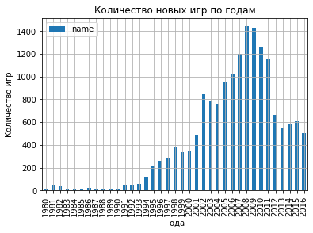

```python
table_year_count_games.plot(kind='bar'
                           , title='Количество новых игр по годам'
                           , grid=True
                           , ylabel = 'Количество игр'
                           , xlabel = 'Года'
#                           , xtick = table_year_count_games['year_of_release'].dt.yaer
                            )
plt.show()
```

**Вывод**: Как мы видим активный рост начался в 1990 году и даже достигал геометричекой прогрессии. Так продолжалось до 2008 года. 2009, 2010 и 2011 оставались очень активными. А позже началась стабилизация на новом уровне 500-700 игр в год.

**Важны ли данные за все периоды?** Это очень хороший вопрос. Особенно, учитывая, что по теории вероятности мы просто более красиво гадаем на кофейной гуще, а исторически: чем больше мы помним и значем тем лучше, чтобы подготовиться. Практически, в данном случае для нас важен тот период, который будет похож на период, который мы пытаемся предсказать, тоесть:

- какие игровые платформы пользуются спросом, и общий уровень "железа"
- у каких игр жизненные циклы будут продолжаться
- какой процент новых игр становится популярными в первые года.
- какие компании выпускают популярные игры, и что они планируют
- покупательская способность наших клиентов
- предпочтения категорий клиентов(например, по возрасту) по жанрам, по используемым ими платформам

и еще много другое.

По моему мнению, сейчас технологические рывки в "железе" более мягкие, чем в сейчас, поэтому лучше брать период из прошлого от 5 до 10 лет для определения общей тенденции рынка, а для расчета годовой перспективы от 1 до 3 лет.

### Продажи по платформам

Составим таблицу по продажам игр на платформах по годам.

**Важно**: Необходимо предупредить, что данные не очень, корректны для понимания, так как указанные года, это года выпуска игры в продажу. Но игра может продаваться больше 1 года, например, 10 лет! Но в этой таблице мы запишем все продажи до 2016 года по этой игре именно в год ее выпуска.

```python
data.pivot_table(index=['platform', 'year_of_release'], values= 'total_sales', aggfunc= 'sum')
```

| platform | year_of_release | total_sales |
| --- | --- | --- |
| 2600 | 1980 | 11.38 |
|  | 1981 | 35.68 |
|  | 1982 | 28.88 |
|  | 1983 | 5.84 |
|  | 1984 | 0.27 |
|  | 1985 | 0.45 |
|  | 1986 | 0.67 |
|  | 1987 | 1.94 |
|  | 1988 | 0.74 |
|  | 1989 | 0.63 |
|  | 1994 | 2.53 |
| 3DO | 1994 | 0.02 |
|  | 1995 | 0.08 |
| 3DS | 2011 | 63.20 |
|  | 2012 | 51.76 |
|  | 2013 | 56.57 |
|  | 2014 | 43.76 |
|  | 2015 | 27.78 |
|  | 2016 | 15.14 |
| DC | 1998 | 3.38 |
|  | 1999 | 5.16 |
|  | 2000 | 5.99 |
|  | 2001 | 1.07 |
|  | 2002 | 0.29 |
|  | 2007 | 0.02 |
|  | 2008 | 0.04 |
| DS | 2004 | 17.27 |
|  | 2005 | 130.14 |
|  | 2006 | 119.81 |
|  | 2007 | 147.23 |

[output cut: 209 more lines]

Нарисуем графики продаж игр в штуках по годам их выпуска для каждой платформы. И подготовим данные для определения ТОП-10 платформ по продажам с 1980 по 2016 года.

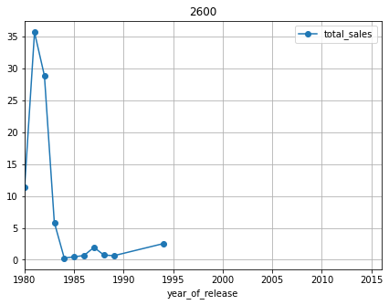

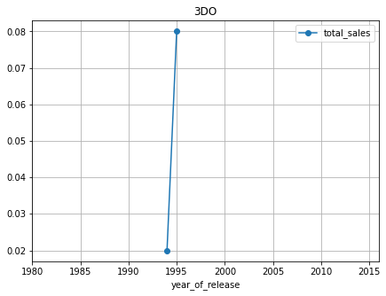

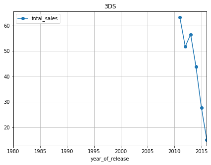

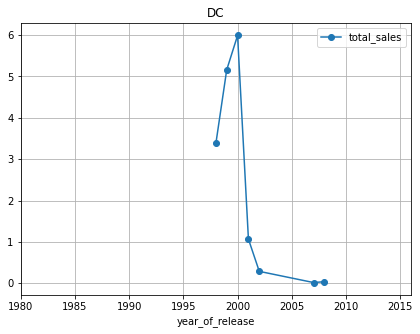

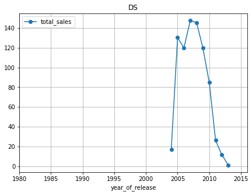

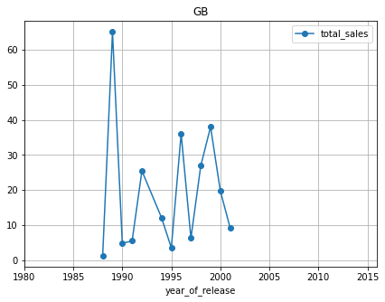

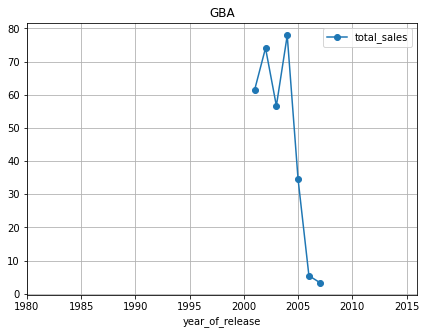

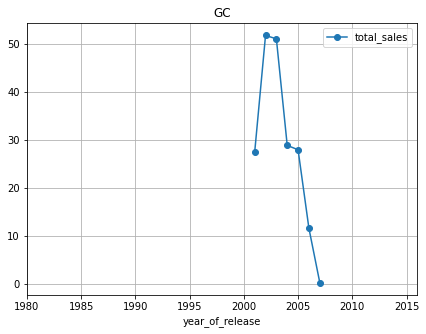

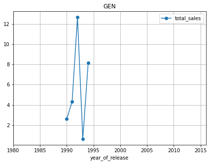

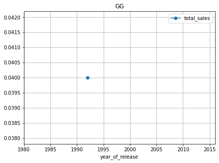

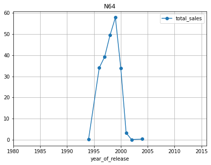

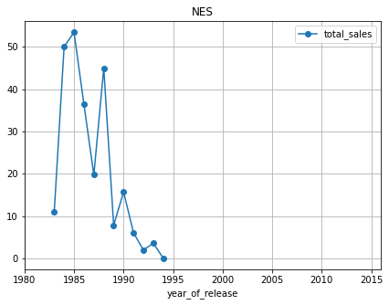

[19 more figures not shown]

```python
# сюда мы запишем пары: название платформы и количество продаж в млн штук, а так же накопим
# информацию о количестве лет, когда появляются новые игры для платформ
platforms_all_sales = pd.DataFrame(columns=['platform', 'all_sales',
                                            'active_year_platform',
                                            'na_all_sales', 'jp_all_sales',
                                            'eu_all_sales', 'other_all_sales']) # факультативно по регионам
# грамотно нарежем базу для каждой платформы
# сводная таблица для каждой платформы
# нарисуем графики для каждой платформы
for column_name, column_slice in data.groupby('platform'):
    column_slice.pivot_table(index = 'year_of_release', values='total_sales', aggfunc='sum')\
                .plot(grid=True
                     , legend=True
                     , figsize=(7, 5)
                     , xlim= (1980, 2016)
#                     , ylim=(0, 1.3)
                      , title = column_name
                      , label =column_name
                      , style='o-'
#                      , kind='hist'
#                      , histtype='step'
#                      ,bins=36
                     )
    # накопим данные по сумму всех продаж на каждой платформе. А так же активных годах написания игр для платформы
    platforms_all_sales = platforms_all_sales.append({'platform': column_name,
                                                      'all_sales': column_slice['total_sales'].sum()
                                                     , 'jp_all_sales' :column_slice['jp_sales'].sum() # факультативно по регионам
                                                      , 'eu_all_sales' :column_slice['eu_sales'].sum()
                                                      , 'na_all_sales' :column_slice['na_sales'].sum()
                                                      , 'other_all_sales' :column_slice['other_sales'].sum()
                                                      , 'active_year_platform': len(column_slice['year_of_release'].unique())
                                                     }
                                                     , ignore_index=True)
```

После первого построения графиков были обнаружены платформы, для которых игры были написаны слишком рано. Вернемся назад и сделаем проверку для этих платформ: 3DS, DS, GBA, PS2, PS3, Wii, X360. Пункт 2.4.3 выполнен. Наши графики выше исправились.

Теперь путем несложной сортировки определим ТОП-10. Можем и ТОП-31, но нас об этом не просили.

**ТОП-10 платформ по всем продажам.**

```python
platforms_all_sales.sort_values(by='all_sales', ascending=False, inplace=True, ignore_index=True)
platforms_all_sales.head(10)
```

|  | platform | all_sales | active_year_platform | na_all_sales | jp_all_sales | eu_all_sales | other_all_sales |
| --- | --- | --- | --- | --- | --- | --- | --- |
| 0 | PS2 | 1249.97 | 12 | 581.55 | 137.78 | 337.98 | 192.66 |
| 1 | X360 | 965.64 | 12 | 598.71 | 12.33 | 269.36 | 85.24 |
| 2 | PS3 | 933.35 | 11 | 391.19 | 79.47 | 328.29 | 134.40 |
| 3 | Wii | 902.28 | 11 | 493.15 | 69.05 | 261.38 | 78.70 |
| 4 | DS | 803.84 | 10 | 380.99 | 175.00 | 188.72 | 59.13 |
| 5 | PS | 729.04 | 10 | 335.53 | 139.78 | 212.94 | 40.79 |
| 6 | PS4 | 314.14 | 4 | 108.74 | 15.96 | 141.09 | 48.35 |
| 7 | GBA | 313.55 | 7 | 184.60 | 46.56 | 74.77 | 7.62 |
| 8 | PSP | 293.57 | 12 | 109.09 | 76.38 | 66.68 | 41.42 |
| 9 | PC | 258.86 | 26 | 94.23 | 0.17 | 142.16 | 22.30 |

ТОП-10 платформ по продажам в Европе.

```python
platforms_all_sales.sort_values(by='eu_all_sales', ascending=False, ignore_index=True)['platform'].head(10)
```

```
0     PS2
1     PS3
2    X360
3     Wii
4      PS
5      DS
6      PC
7     PS4
8     GBA
9     PSP
Name: platform, dtype: object
```

ТОП-10 платформ по продажам в Северной Америке.

```python
platforms_all_sales.sort_values(by='na_all_sales', ascending=False, ignore_index=True)['platform'].head(10)
```

```
0    X360
1     PS2
2     Wii
3     PS3
4      DS
5      PS
6      XB
7     GBA
8     N64
9      GC
Name: platform, dtype: object
```

ТОП-10 платформ по продажам в Японии.

```python
platforms_all_sales.sort_values(by='jp_all_sales', ascending=False, ignore_index=True)['platform'].head(10)
```

```
0      DS
1      PS
2     PS2
3    SNES
4     3DS
5     NES
6      GB
7     PS3
8     PSP
9     Wii
Name: platform, dtype: object
```

ТОП-10 платформ по продажам в других регионах.

```python
platforms_all_sales.sort_values(by='other_all_sales', ascending=False, ignore_index=True)['platform'].head(10)
```

```
0     PS2
1     PS3
2    X360
3     Wii
4      DS
5     PS4
6     PSP
7      PS
8      PC
9    XOne
Name: platform, dtype: object
```

Теперь разберемся с вопросом:**"За какой характерный срок появляются новые и исчезают старые платформы?"**

```
count    31.000000
mean      7.709677
std       5.087197
min       1.000000
25%       4.000000
50%       7.000000
75%      11.000000
max      26.000000
Name: active_year_platform, dtype: float64
```

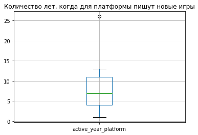

```python
platforms_all_sales['active_year_platform'] = pd.to_numeric(platforms_all_sales['active_year_platform'], downcast='signed')
display(platforms_all_sales['active_year_platform'].describe())
platforms_all_sales.boxplot(column=['active_year_platform'])
plt.title('Количество лет, когда для платформы пишут новые игры')
plt.show()
```

С учётом замечания выше, вопрос нужно перефразировать на: "** Сколько лет после появления платформы производители игр создают игры для этой платформы?**"

Как раз у разработчиков платформ есть время, чтобы запустить новую платформу.

**Выводы для 1980-2016 годов.**:

- Японцы сами себе на уме и любят играть в свои игры. Но геймеров у них не много, и рейтинг определяют другие.
- По остальным рынкам и в общем ТОП-4 меняются местами, но состав все тот же. ТОП-4 (2016):
  - PS2
  - X360
  - PS3
  - Wii
- Северо-американцы и европейцы играют много, и покупают игр тоже много. Их рынки главные.
- В среднем для платформ пишут игры 7-8 лет. А для ТОП-4 - 10 и более лет.
- Рассмотрена 31 платформа.

### Актуальный период

Так как мы опредили, что для платформ в среднем пишут игры 7-8 лет, а считаются их продажи в год, когда они выпустились, то возьмём **актуальный период = 8/2 = 4 годам (2013-2016 года)**.

По опыту 3-4 года для игры это период актуальности и популярности игр. Так что оценка интуитивно хорошая.

Сделаем анализ для этого актуального периода, чтобы сделать прогнозы на 2017 год, **не учитывая предыдущие года (1980-2012)**.

Проверим наши утверждения из предыдущего пункта для нового актуального периода 2013-2016 года. Конечно, вопрос о сроках актуальности платформ здесь уже не актуален.

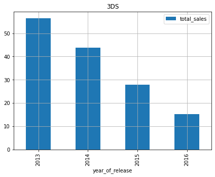

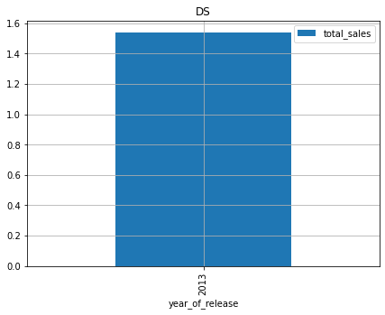

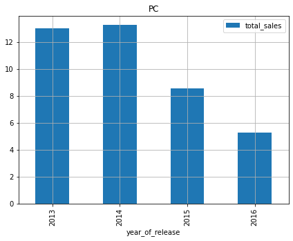

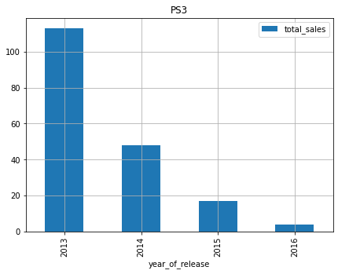

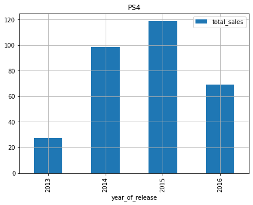

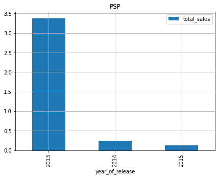

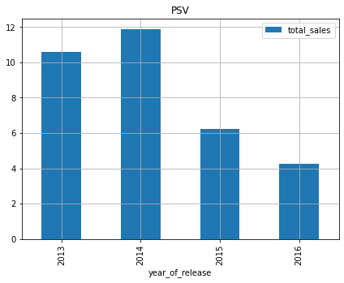

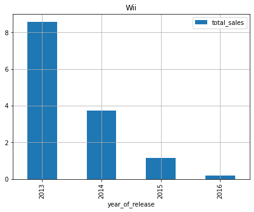

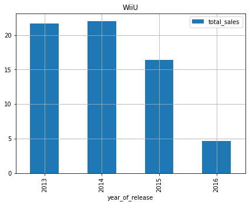

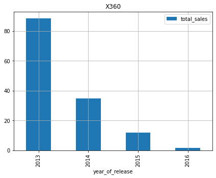

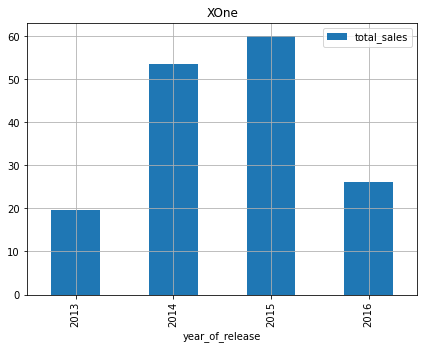

```python
# актуальный период
actual_period = [2013, 2014, 2015, 2016]

# сюда мы запишем пары: название платформы и количество продаж в млн штук, а так же накопим
# информацию о количестве игр на платформе
platforms_all_sales = pd.DataFrame(columns=['platform', 'all_sales',
                                            'count_names_on_platform',
                                            'na_all_sales', 'jp_all_sales',
                                            'eu_all_sales', 'other_all_sales']) # факультативно по регионам
# грамотно нарежем базу для каждой платформы
# сводная таблица для каждой платформы
# нарисуем графики для каждой платформы
# актуальный период с 2013 по 2016 года
for column_name, column_slice in data.query('year_of_release in @actual_period').groupby('platform'):
    column_slice.pivot_table(index = 'year_of_release', values='total_sales', aggfunc='sum').plot(grid=True
                     , legend=True
                     , figsize=(7, 5)
                     , xlim= (2013, 2016)
#                     , ylim=(0, 1.3)
                      , title = column_name
                      , label =column_name
#                      , style='o-'
                      , kind='bar'
#                      , histtype='step'
#                      ,bins=36
                     )
    # накопим данные по сумму всех продаж на каждой платформе. А так же активных годах написания игр для платформы
    platforms_all_sales = platforms_all_sales.append({'platform': column_name,
                                                      'all_sales': column_slice['total_sales'].sum()
                                                     , 'jp_all_sales' :column_slice['jp_sales'].sum() # факультативно по регионам
                                                      , 'eu_all_sales' :column_slice['eu_sales'].sum()
                                                      , 'na_all_sales' :column_slice['na_sales'].sum()
                                                      , 'other_all_sales' :column_slice['other_sales'].sum()
                                                      , 'count_names_on_platform': len(column_slice['name'].unique())
                                                     }
                                                     , ignore_index=True)
```

#### ТОП-10 платформ по всем продажам (больше похоже на 11, но последнему было бы обидно остаться без внимания)

```python
platforms_all_sales.sort_values(by='all_sales', ascending=False, inplace=True, ignore_index=True)
platforms_all_sales
```

|  | platform | all_sales | count_names_on_platform | na_all_sales | jp_all_sales | eu_all_sales | other_all_sales |
| --- | --- | --- | --- | --- | --- | --- | --- |
| 0 | PS4 | 314.14 | 392 | 108.74 | 15.96 | 141.09 | 48.35 |
| 1 | PS3 | 181.43 | 345 | 63.50 | 23.35 | 67.81 | 26.77 |
| 2 | XOne | 159.32 | 247 | 93.12 | 0.34 | 51.59 | 14.27 |
| 3 | 3DS | 143.25 | 303 | 38.20 | 67.81 | 30.96 | 6.28 |
| 4 | X360 | 136.80 | 186 | 81.66 | 0.51 | 42.52 | 12.11 |
| 5 | WiiU | 64.63 | 115 | 29.21 | 10.88 | 19.85 | 4.69 |
| 6 | PC | 40.06 | 192 | 11.19 | 0.00 | 25.84 | 3.03 |
| 7 | PSV | 32.99 | 358 | 5.04 | 18.59 | 6.10 | 3.26 |
| 8 | Wii | 13.66 | 23 | 6.56 | 0.05 | 5.93 | 1.12 |
| 9 | PSP | 3.74 | 68 | 0.00 | 3.53 | 0.17 | 0.04 |
| 10 | DS | 1.54 | 8 | 0.57 | 0.00 | 0.85 | 0.12 |

**Выводы для 2013-2016 годов.**:

- Японцы сами себе на уме и любят играть в свои игры. Но геймеров у них не много, и рейтинг определяют другие.
- По остальным рынкам и в общем ТОП-5 меняются местами, но состав все тот же. ТОП-5 (2016):
  - PS4
  - PS3
  - XOne
  - 3DS
  - X360
- Северо-американцы и европейцы играют много, и покупают игр тоже много. Их рынки главные.
- Всего 11 платформ. С общими продажами более 100 млн всего 5(ТОП-5).

Изменения очень интересны:

- японцы остались японцами, но, то что у них в ТОП-5 может оказаться в ТОП-5 по всему миру в следующие года.
- ТОП-4 увеличился до ТОП-5 и сильно поменялся.
- Северо-американци и европейцы продолжают играть больше всех. Европейцы продолжают любить PC(старая школа- уважаю).
- Количество платформ 11 вместо 31.

С количеством продаж приблизительно понятно из рейтинга.

**А как продаются игры?**

Из графиков выше мы видим, что более свежие платформы:

- PS4,
- XOne,
- WiiU,

Активно продают игры выпущенные в 2015 и 2014 годах. Поэтому их графики "с горбинкой" на 2015 и 2014 годах.

А более старые платформы:

- PS3
- 3DS
- X360
- и другие...

Активно продают игры выпущенные ранее, очевиден **эффект накопления**, поэтому их графики снижающиеся от года в год.

Игры выпущенные в 2016 году еще не накопили продажи.

### Актуальные платформы

Пусть **актуальными платформами** будут платформы, которые продаются в *актуальный период*.

```python
# на будующее сохраним в порядке по уменьшению продаж
actual_platforms = platforms_all_sales.sort_values(by='all_sales', ascending=False, ignore_index=True)['platform']
actual_platforms
```

```
0      PS4
1      PS3
2     XOne
3      3DS
4     X360
5     WiiU
6       PC
7      PSV
8      Wii
9      PSP
10      DS
Name: platform, dtype: object
```

### Актуальные данные

Пусть **актуальные данные** - это данные по *актуальным платформам* в *актуальный период*.

```python
# data = data.query('year_of_release in @actual_period and platform in @actual_platforms')
data = data.query('year_of_release in @actual_period')
data.info()
data.head()
```

```
<class 'pandas.core.frame.DataFrame'>
Int64Index: 2237 entries, 16 to 16714
Data columns (total 12 columns):
 #   Column           Non-Null Count  Dtype
---  ------           --------------  -----
 0   name             2237 non-null   object
 1   platform         2237 non-null   object
 2   year_of_release  2237 non-null   Int16
 3   genre            2237 non-null   object
 4   na_sales         2237 non-null   float64
 5   eu_sales         2237 non-null   float64
 6   jp_sales         2237 non-null   float64
 7   other_sales      2237 non-null   float64
 8   critic_score     994 non-null    Int8
 9   user_score       1195 non-null   Int8
 10  rating           2237 non-null   object
 11  total_sales      2237 non-null   float64
dtypes: Int16(1), Int8(2), float64(5), object(4)
memory usage: 190.1+ KB
```

|  | name | platform | year_of_release | genre | na_sales | eu_sales | jp_sales | other_sales | critic_score | user_score | rating | total_sales |
| --- | --- | --- | --- | --- | --- | --- | --- | --- | --- | --- | --- | --- |
| 16 | grand theft auto v | PS3 | 2013 | Action | 7.02 | 9.09 | 0.98 | 3.96 | 97 | 82 | M | 21.05 |
| 23 | grand theft auto v | X360 | 2013 | Action | 9.66 | 5.14 | 0.06 | 1.41 | 97 | 81 | M | 16.27 |
| 31 | call of duty black ops 3 | PS4 | 2015 | Shooter | 6.03 | 5.86 | 0.36 | 2.38 | <NA> | <NA> | noESRB | 14.63 |
| 33 | pokemon x pokemon y | 3DS | 2013 | Role-Playing | 5.28 | 4.19 | 4.35 | 0.78 | <NA> | <NA> | noESRB | 14.60 |
| 42 | grand theft auto v | PS4 | 2014 | Action | 3.96 | 6.31 | 0.38 | 1.97 | 97 | 83 | M | 12.62 |

```python
data.describe()
```

|  | year_of_release | na_sales | eu_sales | jp_sales | other_sales | critic_score | user_score | total_sales |
| --- | --- | --- | --- | --- | --- | --- | --- | --- |
| count | 2237.000000 | 2237.000000 | 2237.000000 | 2237.000000 | 2237.000000 | 994.000000 | 1195.000000 | 2237.000000 |
| mean | 2014.473849 | 0.195704 | 0.175552 | 0.063040 | 0.053661 | 72.032193 | 65.851883 | 0.487957 |
| std | 1.091052 | 0.547291 | 0.512013 | 0.233829 | 0.165553 | 12.835742 | 16.095215 | 1.234181 |
| min | 2013.000000 | 0.000000 | 0.000000 | 0.000000 | 0.000000 | 13.000000 | 2.000000 | 0.010000 |
| 25% | 2014.000000 | 0.000000 | 0.000000 | 0.000000 | 0.000000 | 66.000000 | 58.000000 | 0.030000 |
| 50% | 2014.000000 | 0.020000 | 0.030000 | 0.010000 | 0.010000 | 74.000000 | 70.000000 | 0.110000 |
| 75% | 2015.000000 | 0.150000 | 0.130000 | 0.050000 | 0.040000 | 81.000000 | 78.000000 | 0.400000 |
| max | 2016.000000 | 9.660000 | 9.090000 | 4.350000 | 3.960000 | 97.000000 | 93.000000 | 21.050000 |

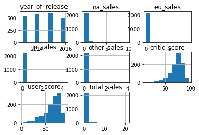

```python
data.hist()
plt.show()
```

```python
data.corr()
```

|  | year_of_release | na_sales | eu_sales | jp_sales | other_sales | critic_score | user_score | total_sales |
| --- | --- | --- | --- | --- | --- | --- | --- | --- |
| year_of_release | 1.000000 | -0.123787 | -0.087915 | -0.073805 | -0.089880 | 0.063217 | 0.038698 | -0.117405 |
| na_sales | -0.123787 | 1.000000 | 0.769967 | 0.264432 | 0.817382 | 0.300506 | -0.020087 | 0.922617 |
| eu_sales | -0.087915 | 0.769967 | 1.000000 | 0.244458 | 0.934783 | 0.280608 | -0.026891 | 0.928005 |
| jp_sales | -0.073805 | 0.264432 | 0.244458 | 1.000000 | 0.195104 | 0.133747 | 0.193740 | 0.434309 |
| other_sales | -0.089880 | 0.817382 | 0.934783 | 0.195104 | 1.000000 | 0.274881 | -0.011493 | 0.921373 |
| critic_score | 0.063217 | 0.300506 | 0.280608 | 0.133747 | 0.274881 | 1.000000 | 0.502702 | 0.313234 |
| user_score | 0.038698 | -0.020087 | -0.026891 | 0.193740 | -0.011493 | 0.502702 | 1.000000 | -0.002605 |
| total_sales | -0.117405 | 0.922617 | 0.928005 | 0.434309 | 0.921373 | 0.313234 | -0.002605 | 1.000000 |

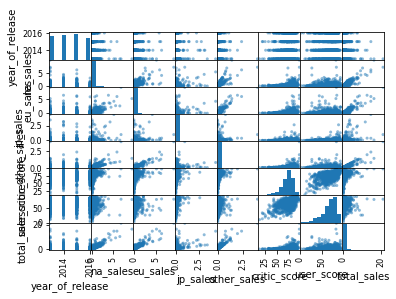

```python
pd.plotting.scatter_matrix(data)
plt.show()
```

Будем использовать *актуальные данные* для прогнозирования 2017 года.

### Актуальный анализ платформ и игр на них

В данном разделе мы на основе *актуальных данных* посчитаем и нарисуем:

- статистику общих продаж игр по платформам,
- "ящик с усами" для общих продаж игр для платформ по актуальным годам,
- корреляцию общих продаж с отзывами критиков и пользователей,
- графики рассеивания и ячеестые графики для общих продаж и отзывов критиков и пользователей.